# What’s all this Bayesian whatnot, anyway?

## Objective

I want to explore the fundamental ideas of Bayesian statistics theoretically through Wasserman’s *All of Statistics*, whilst also writing simulations and trying out various computational methods.Possibly most important of these will be `greta`.

## Packages

```r
library(tidyverse)
```

## Tasks

- Start at the start
- Understand nonres problem, but need to decypher the problem before pushing it.
- Don’t forget to build classical frequentist models alongside the Bayesian and machine learning algorithms.

## Start at the start

Wasserman begins his discussion of Bayesian inference thus.

Bayesian inference is usually carried out in the following way.

1. We choose a probability density $f(θ)$ — called the *prior* distribution — that expresses our beliefs about a parameter $θ$ before we see any data.
2. We choose a *statistical model* $f(x|θ)$ that reflects our beliefs about $x$ given $θ$. Notice that we now write this as $f(x|θ)$ instead of $f(x; θ)$.
3. After observing data $X_1,...,X_n$, we update our beliefs and calculate the *posterior* distribution $f(θ|X_1,...,X_n)$.

> How to unpack these ideas? Try discrete and continuous, one, two, and m, parameters. Discrete has logical and multi-level. Approach multi-level discrete after doing logical discrete and continuous. There’s also ordinal. This could eventually extend into a seperate docuemnt, if it gets away from me. And then there’s the influence of moderators.

This is a process of inference. So, there is some population parameter $\theta$ of interest, and some sample of data from which we want to infer information about the unknown paramaeter $\theta$. Using properties of joint probability we can extend this idea to multiple parameters of interest.

In a frequentist setting, we might say the random variable $X$ is i.i.d., so $X_i \sim N(\mu, \sigma^2)$ for some simple random sample $X_1, X_2, \dots, X_n$. We would assume that the key parameters $\mu$ and $\sigma$ are fixed.

In a Bayesian setting, *everything* is a map, both random variables and parameters. I suppose I could consider the frequentist setting the special case where the parameters have fixed-value maps.

## An example scenario

Misclassification problem - NB must rename variables in this before pushing it.

Suppose we have some peeps and they are given the option of eating canteloupe. The question is, does canteloupe eating enable us to classify the peep as a kittykitty or a humanslave?

```r
names <- c("dr x", "pandagrrRl", "patches", "beanie", "euclid")
```

and they have been classified (we will randomly assign classfication) as `humanslave` or `kittykitty`.

```r
kitty_class <- tibble(
  names,
  classification = sample(c("kittykitty", "humanslave"), length(names), replace = T))

# Take a look.
kitty_class %>% knitr::kable()
```

| names | classification |
| --- | --- |
| dr x | humanslave |
| pandagrrRl | humanslave |
| patches | humanslave |
| beanie | humanslave |
| euclid | kittykitty |

Now, we have a known and measurable variable, whether or not that person eats the canteloupe.

```r
kitty_class <- kitty_class %>%
  mutate(canteloupe = c(F, T, T, F, F))

# Take a look.
kitty_class %>%
  knitr::kable()
```

| names | classification | canteloupe |
| --- | --- | --- |
| dr x | humanslave | FALSE |
| pandagrrRl | humanslave | TRUE |
| patches | humanslave | TRUE |
| beanie | humanslave | FALSE |
| euclid | kittykitty | FALSE |

The question is, can we use canteloupe as a classifer for `kittykitty`ness?

> I suppose I could use a different classifier to experiment with when it is truly associated or not. In this case, there is no association.

> I also wonder if this can be extended to a multinomial allowing for more than one type of misclassification.

```r
tibble(
  names,
  catriarchy = c("humanslave", "humanslave", rep("kittykitty", 3))
) %>%
  right_join(kitty_class, by = "names") %>%
  mutate(misclassified = classification != catriarchy) -> kitty_class
```

## A simple logistic regression model

```r
# Fit a glm
kitty_logistic <- glm(misclassified ~ canteloupe,
                      data = kitty_class,
                      family = "binomial")

# Take a look at the results.
kitty_logistic %>% broom::glance()
```

```
##   null.deviance df.null    logLik      AIC     BIC deviance df.residual
## 1      6.730117       4 -3.295837 10.59167 9.81055 6.591674           3
```

```r
kitty_logistic %>% broom::tidy()
```

```
##             term   estimate std.error  statistic   p.value
## 1    (Intercept) -0.6931472  1.224745 -0.5659524 0.5714261
## 2 canteloupeTRUE  0.6931472  1.870829  0.3705028 0.7110079
```

```r
kitty_logistic %>% broom::augment()
```

```
##   misclassified canteloupe    .fitted  .se.fit     .resid      .hat
## 1         FALSE      FALSE -0.6931472 1.224745 -0.9005166 0.3333333
## 2         FALSE       TRUE  0.0000000 1.414214 -1.1774100 0.5000000
## 3          TRUE       TRUE  0.0000000 1.414214  1.1774100 0.5000000
## 4          TRUE      FALSE -0.6931472 1.224745  1.4823038 0.3333333
## 5         FALSE      FALSE -0.6931472 1.224745 -0.9005166 0.3333333
##     .sigma .cooksd .std.resid
## 1 1.639402  0.1875  -1.102903
## 2 1.381862  1.0000  -1.665109
## 3 1.381862  1.0000   1.665109
## 4 1.283713  0.7500   1.815444
## 5 1.639402  0.1875  -1.102903
```

## Running through the greta example

```r
library(greta)
```

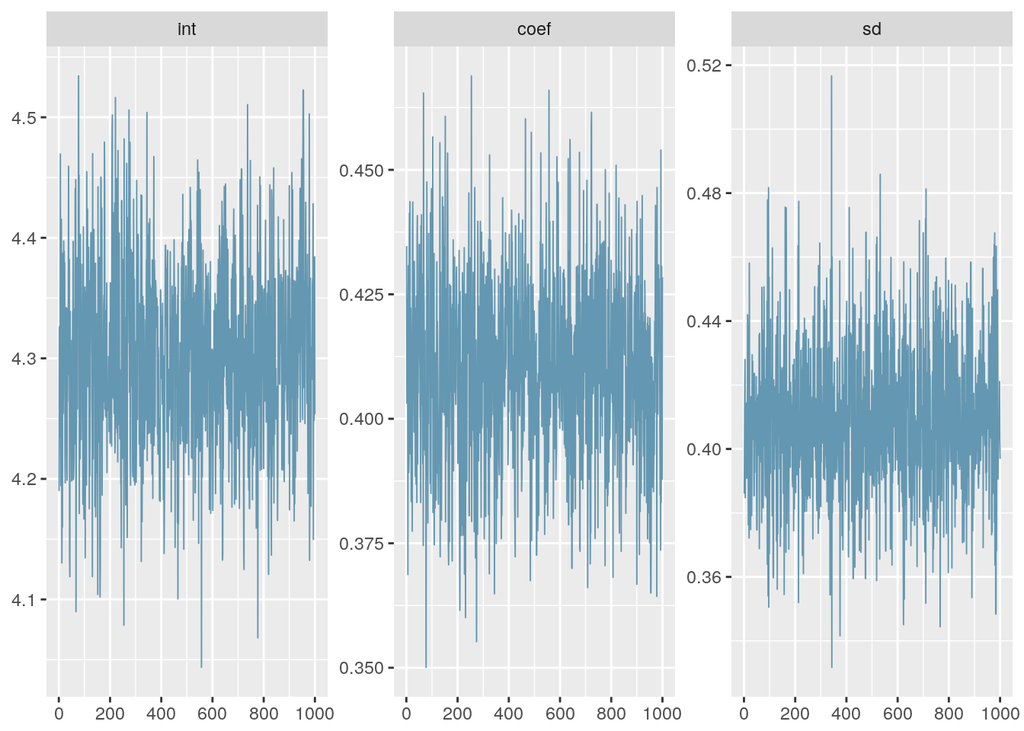

```r
x <- iris$Petal.Length
y <- iris$Sepal.Length

library(greta)

int <- normal(0, 5)
coef <- normal(0, 3)
sd <- lognormal(0, 3)

mean <- int + coef * x
distribution(y) <- normal(mean, sd)

m <- model(int, coef, sd)

# Throws error for chains argument.
draws <- greta::mcmc(m, n_samples = 1000)

bayesplot::mcmc_trace(draws)
```